```python
from IPython.display import HTML
```

```python
HTML('''<script>
code_show=true;
function code_toggle() {
 if (code_show){
 $('div.input').hide();
 } else {
 $('div.input').show();
 }
 code_show = !code_show
}
$( document ).ready(code_toggle);
</script>
The raw code for this IPython notebook is by default hidden for easier reading.
To toggle on/off the raw code, click <a href="javascript:code_toggle()">here</a>.''')
```

The raw code for this IPython notebook is by default hidden for easier reading. To toggle on/off the raw code, click here.

# Udacity Nano Degree - Open Street Map - Neuruppin, Germany

I decided first to take Elgin Texas in the United States of America as dear friends are living there and one day I want to visit them. But I found out that the source data is only 10MB large. So I had to find an alternative and decided to take Neuruppin in Germany, where I spent some time when I met my husband and programmed a database for the firefighter station. The Neuruppin OSM file is 150 MB big.

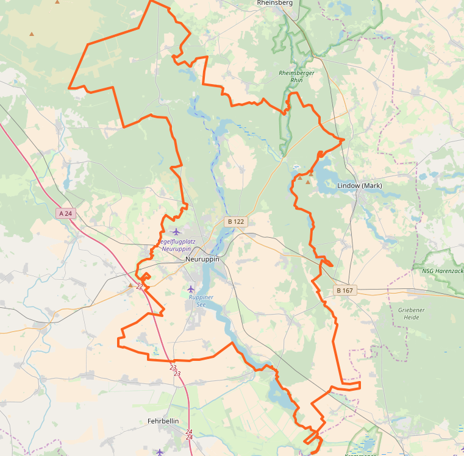

```python
#Display the screenshot from Openstreetmap (source: stackoverflow)

from IPython.display import Image
Image(filename='Neuruppin.png')
```

## Map Data from openstreetmap.org for Neuruppin

The Data is downloaded as osm file. The xml data contains nodes which are id numbers and pairs of coordinates, shape a way and can be included as member of realtions. Ways are ordered lists and relations are multipurpose data structure. Tags: meaning of particular element to which they are attached, free text format fields: keys and values. (source: open street map documentation)

To analyse and wrangle the data I plan to follow the Blueprint for data cleaning procedure from the Udacity (Block Data Wrangling with MongoDB).

- audit data
- create data cleaning plan
  - identify causes
  - define operations
  - test
- excecute plan
- manually correct if needed
- harmonize data

Checking the Data Quality follows generally these questions: (source: Udacity, medium.com)

- Does the data conform to a standard format?
- Accuracy: Does the data agree with reality or with a trusted external source?
- Completeness: Are all records present?
- Consistency: Is data in a field (down a column) or for an instance (across a row) in logical agreement?
- Uniformity: Are the same units used across a given field?

Problems I am looking for in the data:

- Abbreviated street types
- Incomplete post code
- do the telphone numbers follow a standard
- Redundant data values
- missing and or NaN data
- what are the 'highlights' in Neuruppin (restaurants, museum, etc.)

## Screenshot on the OSM file

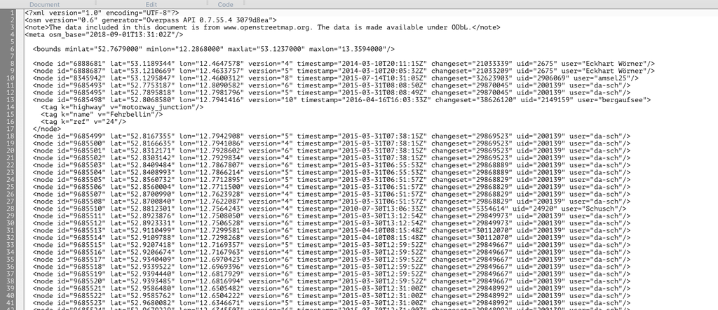

```python
from IPython.display import Image
Image(filename='osmsnip.png')
```

The data primitives are Nodes ( id no, and pair of coordinates) and they shape a way as well as they can be included as member of relation. A node is a lat/lon pair.

A way is an ordered list, a list of at least two node references describing a linear feature. Ways can be closed, in which case the first and the last node are identical. Areas are not explicitly represented in OSM, but are identified via community-approved tags.

Relations are multipurpose data structure, a group of zero or more primitives with an associated role.

Tags are the meaning of particular elements to which they are attached, free format field text: key and value.

All data in OSM are in the WGS-84 datum. (source docs.save.com)

```python
#import of libraries
import xml.etree.cElementTree as ET
from collections import defaultdict
import re
import pprint
```

```python
#making the  map available, read mode
osm_file = open ("map.osm", "r")
```

```python
print(osm_file)
```

```
<_io.TextIOWrapper name='map.osm' mode='r' encoding='UTF-8'>
```

### Quantification of a number of parameters to get an overall view of the data.

```python
#parse the map
#frequency of each first-level tag
def count_tags(osmfile):
    tags = {}
    for event, node in ET.iterparse(osmfile):
        tag = node.tag
        if tag and not tag in tags.keys():
            tags[tag] = 0
        tags[tag] = tags[tag] + 1
    return tags

def run():
    tags = count_tags("map.osm")
    pprint.pprint(tags)

if __name__ == "__main__":
    run()
```

```
{'bounds': 1,
 'member': 59336,
 'meta': 1,
 'nd': 887176,
 'node': 649570,
 'note': 1,
 'osm': 1,
 'relation': 1384,
 'tag': 265673,
 'way': 98622}
```

Grouping the node keys into four groups: (source: Udacity case study, GitHub)

```
- lower for lower cases which are valid
- lower colon for valid tags with colon
- problem chars for problematic characters
- other for not falling into one of the above groups
```

```python
def audit_tags(osmfile):
    """Audit the osmfile and return sets of node tag keys, node tag values, way tag keys and way tag values"""
    osm_file = open(osmfile, "r")
    node_tags_keys = set()
    node_tags_values = set()
    way_tags_keys = set()
    way_tags_values = set()

    for event, elem in ET.iterparse(osm_file, events=("start",)):
        if elem.tag == "node": #only check way and node
            for tag in elem.iter('tag'):
                node_tags_keys.add(tag.attrib['k'])
                node_tags_values.add(tag.attrib['v'])
        if elem.tag == "way": #only check way and node
            for tag in elem.iter('tag'):
                way_tags_keys.add(tag.attrib['k'])
                way_tags_values.add(tag.attrib['v'])
    osm_file.close()
    return node_tags_keys, node_tags_values, way_tags_keys, way_tags_values

osm_file = "map.osm"
node_tags_keys, node_tags_values, way_tags_keys, way_tags_values  = audit_tags(osm_file)

lower = re.compile(r'^([a-z]|_)*$', re.IGNORECASE)
lower_colon = re.compile(r'^([a-z]|_)*:([a-z]|_)*$', re.IGNORECASE)
problemchars = re.compile(r'[=\+/&<>;\'"\?%#$@\,\. \t\r\n]', re.IGNORECASE)
# case insensitive search

def tag_keys(tag_keys_set):
    """Return sets of different types of keys"""
    lower_keys = set()
    lower_colon_keys = set()
    problemchars_keys = set()
    others_keys = set()

    for key in tag_keys_set:
        if lower.search(key):
            lower_keys.add(key)
        elif lower_colon.search(key):
            lower_colon_keys.add(key)
        elif problemchars.search(key):
            problemchars_keys.add(key)
        else:
            others_keys.add(key)

    return lower_keys,lower_colon_keys,problemchars_keys,others_keys

node_lower_keys,node_lower_colon_keys,node_problemchars_keys,node_others_keys = tag_keys(node_tags_keys)

node_key_types = {"total": len(node_tags_keys),"lower":len(node_lower_keys),"lower colon":len(node_lower_colon_keys),"problemchars":len(node_problemchars_keys),"others":len(node_others_keys)}

print ("The number of keys for each type is: ")
pprint.pprint(node_key_types)
```

```
The number of keys for each type is:
{'lower': 236,
 'lower colon': 190,
 'others': 131,
 'problemchars': 0,
 'total': 557}
```

```python
#display node_tags_keys
#node_tags_keys
```

```python
# display node_lower_keys
#node_lower_keys
```

## Exploring the data

Osmread is a simple library for reading OpenStreetMap data files in Python. It supports XML and PBF file formats as inputs. It is not designed for fast processing of big planet dumps but can be used for simple processing of smaller files such as regional extracts.

```python
from osmread import parse_file, Way

highway_count = 0
for entity in parse_file('map.osm'):
    if isinstance(entity, Way) and 'highway' in entity.tags:
        highway_count += 1

print("%d highways found" % highway_count)
```

```
20246 highways found
```

```python
amentiy_count = 0
for entity in parse_file('map.osm'):
    if isinstance(entity, Way) and 'amenity' in entity.tags:
          amentiy_count += 1

print("%d ameneties found" % amentiy_count)
```

```
919 ameneties found
```

```python
shop_count = 0
for entity in parse_file('map.osm'):
    if isinstance(entity, Way) and 'shop' in entity.tags:
          shop_count += 1

print("%d shop found" % shop_count)
```

```
106 shop found
```

```python
kayak_rental_count = 0
for entity in parse_file('map.osm'):
    if isinstance(entity, Way) and 'kayak_rental' in entity.tags:
          kayak_rental_count += 1

print("%d kayak_rental found" % kayak_rental_count)
```

```
1 kayak_rental found
```

### Users Identification

```python
#import xml.etree.cElementTree as ET
#import pprint
#import re
"""Investigation on userd who contributed to Neuruppin
The function process_map should return a set of unique users.
"""

#def get_user(element):
#    return

#def process_map(filename):
#    users = set()
#    for _, element in ET.iterparse(filename):
#        tag = element.tag
#        if tag in ['node', 'way', 'relation']:
#            uniqueu = element.attrib['user']
 #           users.add(uniqueu)
 #   return users

#def test():

#   users = process_map('map.osm')
#    pprint.pprint(users)

#if __name__ == "__main__":
#    test()
```

```
'Investigation on userd who contributed to Neuruppin\nThe function process_map should return a set of unique users.\n'
```

#### The number of unique user is : 836

Top 10 User done in SQL:

```
SELECT e.user, COUNT(*) as num
   ...>         FROM (SELECT user FROM Nodes UNION ALL SELECT user FROM Ways) e
   ...>         GROUP BY e.user
   ...>         ORDER BY num DESC
   ...>         LIMIT 10;

atpl_pilot|262447
jacobbraeutigam|43396
Hans Wurst|30416
Shmias|24251
Heideammer|20357
cupofcoffee|17992
gjall1973|16406
Pfad-Finder|15843
Sheendra|13220
kaiD|12077
```

### Investigation on the street types

```python
#code source Udacity - Example on blueprint
import xml.etree.cElementTree as ET
from collections import defaultdict
import re

osm_file = open("map.osm", "r")

street_type_re = re.compile(r'\S+\.?$', re.IGNORECASE)
street_types = defaultdict(int)
regex = re.compile(r'\b\S+\.?', re.IGNORECASE)

expected = ["Strasse", "Weg", "Allee"]

mapping = { "Str":"Strasse",
            "Straße":"Strasse"}

# Search string for the regex. If it is matched and not in the expected list then add this as a key to the set.
def audit_street(street_types, street_name):
    m = regex.search(street_name)
    if m:
        street_type = m.group()
        if street_type not in expected:
            street_types[street_type].add(street_name)

def is_street_name(elem): # Check if it is a street name
    return (elem.attrib['k'] == "addr:street")

def audit(osm_file): # return the list that satify the above two functions
    osm_file = open("map.osm", "r")
    street_types = defaultdict(set)
    for event, elem in ET.iterparse(osm_file, events=("start",)):

        if elem.tag == "node" or elem.tag == "way":
            for tag in elem.iter("tag"):
                if is_street_name(tag):
                    audit_street(street_types, tag.attrib['v'])

    return street_types

pprint.pprint(dict(audit(osm_file))) # print the existing names

def string_case(s): # change string into titleCase except for UpperCase
    if s.isupper():
        return s
    else:
        return s.title()

# return the updated names
def update_name(name, mapping):
    name = name.split(' ')
    for i in range(len(name)):
        if name[i] in mapping:
            name[i] = mapping[name[i]]
            name[i] = string_case(name[i])
        else:
            name[i] = string_case(name[i])

    name = ' '.join(name)


    return name

update_street = audit(osm_file)

# print the updated names
for street_type, ways in update_street.items():
    for name in ways:
        better_name = update_name(name, mapping)
        print (name, "=>", better_name)
```

```
{'Ablage': {'Ablage'},
 'Ahornallee': {'Ahornallee'},
 'Ahornsteig': {'Ahornsteig'},
 'Ahornstraße': {'Ahornstraße'},
 'Ahornweg': {'Ahornweg'},
 'Akaziensteg': {'Akaziensteg'},
 'Akazienstraße': {'Akazienstraße'},
 'Akazienweg': {'Akazienweg'},
 'Alt': {'Alt Ruppiner Straße', 'Alt Ruppiner Allee'},
 'Alte': {'Alte Grüneberger Landstraße', 'Alte Zippelsförder Landstraße'},
 'Alter': {'Alter Dechtower Weg'},
 'Altes': {'Altes Forsthaus'},
 'Am': {'Am Alten Gutshof',
        'Am Alten Gymnasium',
        'Am Anger',
        'Am Bahnhof',
        'Am Biotop',
        'Am Bollwerk',
        'Am Bützsee',
        'Am Dorfanger',
        'Am Fehrbelliner Tor',
        'Am Feldrain',
        'Am Gleis',
        'Am Gudelack',
        'Am Gudelacksee',
        'Am Hang',
        'Am Hasenwinkel',
        'Am Heideberg',
        'Am Heidering',
        'Am Heideweg',
        'Am Hellsee',
        'Am Hohen Bruch',
        'Am Kanal',
        'Am Kirchplatz',
        'Am Klappgraben',
        'Am Königsgraben',
        'Am Langen Luch',
        'Am Markt',
        'Am Mittelfeld',
        'Am Mühlenbach',
```

[output cut: 1208 more lines]

```
Finkstraße => Finkstraße
Eisvogelstraße => Eisvogelstraße
Starstraße => Starstraße
Lerchenstraße => Lerchenstraße
Schwalbenstraße => Schwalbenstraße
Wachtelstraße => Wachtelstraße
Nachtigallstraße => Nachtigallstraße
Haselweg => Haselweg
Erich-Dieckhoff-Straße => Erich-Dieckhoff-Straße
Heidelberger Straße => Heidelberger Strasse
Stauffenbergstraße => Stauffenbergstraße
Rudolf-Breitscheid-Str. => Rudolf-Breitscheid-Str.
Kastanienallee => Kastanienallee
Nutriaweg => Nutriaweg
Mühlenfeld => Mühlenfeld
```

#### Checking Post Codes

```python
zip_codes = [16816,16818,16827,16033,16035] #ZipCodes for Neuruppin
bad_zips = []  # Postcodes that cannot be converted to an integer
suspect_zip_codes = [] # Postcodes outside of the defined area

def audit():
    for _, elem in ET.iterparse(osm_file):
        if elem.tag == 'tag':
            if 'zip' in elem.attrib['k'] or 'postcode' in elem.attrib['k']:
                zip = elem.attrib['v']
                try:
                    zip_codes.add(int(zip))
                except:
                    bad_zips.append(zip)

    for zip_code in zip_codes:
        if zip_code not in zip_codes:
            suspect_zip_codes.add(zip_code)

print (suspect_zip_codes)
print (bad_zips)
print (zip_codes)
```

```
[]
[]
[16816, 16818, 16827, 16033, 16035]
```

### Telephone No Check

```python
import phonenumbers

def update_phonenumber(phonenumber):
    '''fix and standardize phone numbers using phonenumbers module'''
    matches = \
    [match.number for match in phonenumbers.PhoneNumberMatcher(phonenumber, "DE")]
    updated_matches = \
    [phonenumbers.format_number(match,phonenumbers.PhoneNumberFormat.NATIONAL)
        for match in matches]
    phonenumber = ';'.join(updated_matches)
    return phonenumber
```

### Preparing the data to be transferred to SQL treatment

```python
# importing the libraries
import xml.etree.cElementTree as ET
import pprint
import re
from collections import defaultdict
import csv
import codecs
import cerberus
import sqlite3
```

```python
# Here I am building the CSV file from OSM, parse, clean and shape data.


OSM_PATH = "map.osm"

NODES_PATH = "nodes.csv"
NODE_TAGS_PATH = "nodes_tags.csv"
WAYS_PATH = "ways.csv"
WAY_NODES_PATH = "ways_nodes.csv"
WAY_TAGS_PATH = "ways_tags.csv"

LOWER_COLON = re.compile(r'^([a-z]|_)+:([a-z]|_)+')
PROBLEMCHARS = re.compile(r'[=\+/&<>;\'"\?%#$@\,\. \t\r\n]')
regex = re.compile(r'\b\S+\.?', re.IGNORECASE)

#schema = {'name': {'type': 'string', 'maxlength': 10}} http://docs.python-cerberus.org/en/stable/schemas.html

SCHEMA = {
    'node': {
        'type': 'dict',
        'schema': {
            'id': {'required': True, 'type': 'integer', 'coerce': int},
            'lat': {'required': True, 'type': 'float', 'coerce': float},
            'lon': {'required': True, 'type': 'float', 'coerce': float},
            'user': {'required': True, 'type': 'string'},
            'uid': {'required': True, 'type': 'integer', 'coerce': int},
            'version': {'required': True, 'type': 'string'},
            'changeset': {'required': True, 'type': 'integer', 'coerce': int},
            'timestamp': {'required': True, 'type': 'string'}
        }
    },
    'node_tags': {
        'type': 'list',
        'schema': {
            'type': 'dict',
            'schema': {
                'id': {'required': True, 'type': 'integer', 'coerce': int},
                'key': {'required': True, 'type': 'string'},
                'value': {'required': True, 'type': 'string'},
                'type': {'required': True, 'type': 'string'}
            }
        }
    },
    'way': {
        'type': 'dict',
        'schema': {
            'id': {'required': True, 'type': 'integer', 'coerce': int},
            'user': {'required': True, 'type': 'string'},
            'uid': {'required': True, 'type': 'integer', 'coerce': int},
            'version': {'required': True, 'type': 'string'},
            'changeset': {'required': True, 'type': 'integer', 'coerce': int},
            'timestamp': {'required': True, 'type': 'string'}
        }
    },
    'way_nodes': {
        'type': 'list',
        'schema': {
            'type': 'dict',
            'schema': {
                'id': {'required': True, 'type': 'integer', 'coerce': int},
                'node_id': {'required': True, 'type': 'integer', 'coerce': int},
                'position': {'required': True, 'type': 'integer', 'coerce': int}
            }
        }
    },
    'way_tags': {
        'type': 'list',
        'schema': {
            'type': 'dict',
            'schema': {
                'id': {'required': True, 'type': 'integer', 'coerce': int},
                'key': {'required': True, 'type': 'string'},
                'value': {'required': True, 'type': 'string'},
                'type': {'required': True, 'type': 'string'}
            }
        }
    }
}



# Make sure the fields order in the csvs matches the column order in the sql table schema
NODE_FIELDS = ['id', 'lat', 'lon', 'user', 'uid', 'version', 'changeset', 'timestamp']
NODE_TAGS_FIELDS = ['id', 'key', 'value', 'type']
WAY_FIELDS = ['id', 'user', 'uid', 'version', 'changeset', 'timestamp']
WAY_TAGS_FIELDS = ['id', 'key', 'value', 'type']
WAY_NODES_FIELDS = ['id', 'node_id', 'position']


def shape_element(element, node_attr_fields=NODE_FIELDS, way_attr_fields=WAY_FIELDS,
                  problem_chars=PROBLEMCHARS, default_tag_type='regular'):
    """Clean and shape node or way XML element to Python dict"""

    node_attribs = {}
    way_attribs = {}
    way_nodes = []
    tags = []  # Handle secondary tags the same way for both node and way elements

    if element.tag == 'node':
        for key in element.attrib.keys():
            if key in node_attr_fields:
                node_attribs[key] = element.attrib[key]
        for child in element:
            if child.tag == 'tag':
                if problem_chars.search(child.attrib['k']):
                    pass
                else:
                    tags_list = {}
                    tags_list['id'] = element.attrib['id']
                    if child.attrib['k'] == 'name:en':
                        tags_list['value'] = update_name(child.attrib['v'], mapping) ### error???
                    else:
                        tags_list['value'] = child.attrib['v']
                    if LOWER_COLON.search(child.attrib['k']):
                        colon_position = child.attrib['k'].find(':')
                        tags_list['key'] = child.attrib['k'][colon_position+1:]
                        tags_list['type'] = child.attrib['k'][:colon_position]
                    else:
                        tags_list['key'] = child.attrib['k']
                        tags_list['type'] = 'regular'
                    tags.append(tags_list)

    if element.tag == 'way':
        for key in element.attrib.keys():
            if key in way_attr_fields:
                way_attribs[key] = element.attrib[key]
        position = 0
        for child in element:
            if child.tag == 'nd':
                way_nodes_list = {}
                way_nodes_list['id'] = element.attrib['id']
                way_nodes_list['node_id'] = child.attrib['ref']
                way_nodes_list['position'] = position
                position += 1
                way_nodes.append(way_nodes_list)
            if child.tag == 'tag':
                if problem_chars.search(child.attrib['k']):
                    pass
                else:
                    tags_list = {}
                    tags_list['id'] = element.attrib['id']
                    if child.attrib['k'] == 'name:en':
                        tags_list['value'] = update_name(child.attrib['v'], mapping)

                    else:
                        tags_list['value'] = child.attrib['v']
                    if LOWER_COLON.search(child.attrib['k']):
                        colon_position = child.attrib['k'].find(':')
                        tags_list['key'] = child.attrib['k'][colon_position+1:]
                        tags_list['type'] = child.attrib['k'][:colon_position]
                    else:
                        tags_list['key'] = child.attrib['k']
                        tags_list['type'] = 'regular'
                    tags.append(tags_list)

    if element.tag == 'node':
        return {'node': node_attribs, 'node_tags': tags}
    elif element.tag == 'way':
        return {'way': way_attribs, 'way_nodes': way_nodes, 'way_tags': tags}


# ================================================== #
#               Helper Functions                     #
# ================================================== #
def get_element(osm_file, tags=('node', 'way', 'relation')):
    """Yield element if it is the right type of tag"""

    context = ET.iterparse(osm_file, events=('start', 'end'))
    _, root = next(context)
    for event, elem in context:
        if event == 'end' and elem.tag in tags:
            yield elem
            root.clear()


def validate_element(element, validator, schema=SCHEMA):
            """Raise ValidationError if element does not match schema"""
            if validator.validate(element, schema) is not True:
                field, errors = next(validator.errors.items())
                message_string = "\nElement of type '{0}' has the following errors:\n{1}"
                error_string = pprint.pformat(errors)
                raise Exception(message_string.format(field, error_string))


class UnicodeDictWriter(csv.DictWriter, object):
            """Extend csv.DictWriter to handle Unicode input"""
            def writerow(self, row):
                super(UnicodeDictWriter, self).writerow({
                    k: (v.encode('utf-8') if isinstance(v, bytes) else v) for k, v in row.items()
                })
            def writerows(self, rows):
                for row in rows:
                    self.writerow(row)


# ================================================== #
#               Main Function                        #
# ================================================== #
def process_map(file_in, validate):
    """Iteratively process each XML element and write to csv(s)"""

    with codecs.open(NODES_PATH, 'w') as nodes_file,          codecs.open(NODE_TAGS_PATH, 'w') as nodes_tags_file,          codecs.open(WAYS_PATH, 'w') as ways_file,          codecs.open(WAY_NODES_PATH, 'w') as way_nodes_file,          codecs.open(WAY_TAGS_PATH, 'w') as way_tags_file:

        nodes_writer = UnicodeDictWriter(nodes_file, NODE_FIELDS)
        node_tags_writer = UnicodeDictWriter(nodes_tags_file, NODE_TAGS_FIELDS)
        ways_writer = UnicodeDictWriter(ways_file, WAY_FIELDS)
        way_nodes_writer = UnicodeDictWriter(way_nodes_file, WAY_NODES_FIELDS)
        way_tags_writer = UnicodeDictWriter(way_tags_file, WAY_TAGS_FIELDS)

        nodes_writer.writeheader()
        node_tags_writer.writeheader()
        ways_writer.writeheader()
        way_nodes_writer.writeheader()
        way_tags_writer.writeheader()

        validator = cerberus.Validator()

        for element in get_element(file_in, tags=('node', 'way')):
            el = shape_element(element)
            if el:
                if validate is True:
                    validate_element(el, validator)

                if element.tag == 'node':
                    nodes_writer.writerow(el['node'])
                    node_tags_writer.writerows(el['node_tags'])
                elif element.tag == 'way':
                    ways_writer.writerow(el['way'])
                    way_nodes_writer.writerows(el['way_nodes'])
                    way_tags_writer.writerows(el['way_tags'])


if __name__ == '__main__':
    process_map(OSM_PATH, validate=True)
```

# Working on the Database

```python
import sqlite3
from sqlite3 import Error
from sqlite3 import dbapi2 as sq3
import os
import pandas as pd

ourschema = '''
DROP TABLE IF EXISTS 'nodes';
DROP TABLE IF EXISTS 'nodes_tags';
DROP TABLE IF EXISTS 'ways';
DROP TABLE IF EXISTS 'ways_tags';
DROP TABLE IF EXISTS 'ways_nodes';
CREATE TABLE nodes (
    id INTEGER PRIMARY KEY NOT NULL,
    lat REAL,
    lon REAL,
    user TEXT,
    uid INTEGER,
    version INTEGER,
    changeset INTEGER,
    timestamp TEXT
);
CREATE TABLE nodes_tags (
    id INTEGER,
    key TEXT,
    value TEXT,
    type TEXT,
    FOREIGN KEY (id) REFERENCES nodes(id)
);
CREATE TABLE ways (
    id INTEGER PRIMARY KEY NOT NULL,
    user TEXT,
    uid INTEGER,
    version TEXT,
    changeset INTEGER,
    timestamp TEXT
);
CREATE TABLE ways_tags (
    id INTEGER NOT NULL,
    key TEXT NOT NULL,
    value TEXT NOT NULL,
    type TEXT,
    FOREIGN KEY (id) REFERENCES ways(id)
);
CREATE TABLE ways_nodes (
    id INTEGER NOT NULL,
    node_id INTEGER NOT NULL,
    position INTEGER NOT NULL,
    FOREIGN KEY (id) REFERENCES ways(id),
    FOREIGN KEY (node_id) REFERENCES nodes(id)
);'''

PATHSTART="."
dbfile = "neuruppin.db"
def get_db(dbfile):
	'''create the db'''
	sqlite_db = sq3.connect(os.path.join(PATHSTART, dbfile))
	return sqlite_db

def init_db(dbfile, schema):
    """Creates the database tables."""
    db = get_db(dbfile)
    db.cursor().executescript(schema)
    db.commit()
    return db

#Initiate the Database
db=init_db(dbfile, ourschema)
print('Initiated {}'.format(dbfile))

#Read the CSV's and populate with Pandas(if_exist=replace instead of =append solved the IS NULL error)
for f in os.listdir('./CSV_Files/'):
    df=pd.read_csv("./CSV_Files/{}".format(f), sep=',', encoding='utf-8')


    print ('{} populated with {} succesfully!'.format(dbfile,f))
```

```
Initiated neuruppin.db
neuruppin.db populated with ways_tags.csv succesfully!
neuruppin.db populated with nodes_tags.csv succesfully!
neuruppin.db populated with .DS_Store succesfully!
neuruppin.db populated with nodes.csv succesfully!
neuruppin.db populated with ways.csv succesfully!
neuruppin.db populated with ways_nodes.csv succesfully!
```

After the code above buildt the database sucessfully, I imported the csv files via SQLite Studio. Then I am trying to connect this notebook with the database neuruppin.db (source: datacamp course)

```python
#creating database engine
import sqlite3
conn = sqlite3.connect('neuruppin.db')
c = conn.cursor()

print("Opened database successfully")

#table_names = way_tags, nodes_tags, nodes, ways_nodes, ways
```

```
Opened database successfully
```

```python
import sqlite3
import pandas as pd
import numpy as np
import seaborn as sns
import matplotlib.pyplot as plt
%matplotlib inline

# Creating the connection to database
con = sqlite3.connect('neuruppin.db')
cursor = con.cursor()

# display tables
for row in cursor.execute("SELECT name FROM sqlite_master WHERE type='table';"):
    print(row)
```

```
('nodes',)
('nodes_tags',)
('ways',)
('ways_tags',)
('ways_nodes',)
```

```python
#Reading all the TABLES with pandas library
nodes = pd.read_sql_query("SELECT * FROM nodes", con)
nodes_tags = pd.read_sql_query("SELECT * FROM nodes_tags", con)
ways = pd.read_sql_query("SELECT * FROM ways", con)
ways_tags = pd.read_sql_query("SELECT * FROM ways_tags", con)
ways_nodes = pd.read_sql_query("SELECT * FROM ways_nodes", con)
```

```python
#close connection to database
conn.close()
```

```python
# investigation on some data information
nodes.shape

nodes.info()

nodes.head()
```

```
<class 'pandas.core.frame.DataFrame'>
RangeIndex: 649570 entries, 0 to 649569
Data columns (total 8 columns):
id           649570 non-null int64
lat          649570 non-null float64
lon          649570 non-null float64
user         649570 non-null object
uid          649570 non-null int64
version      649570 non-null int64
changeset    649570 non-null int64
timestamp    649570 non-null object
dtypes: float64(2), int64(4), object(2)
memory usage: 39.6+ MB
```

|  | id | lat | lon | user | uid | version | changeset | timestamp |
| --- | --- | --- | --- | --- | --- | --- | --- | --- |
| 0 | 6888681 | 53.118934 | 12.464758 | Eckhart Wörner | 2675 | 4 | 21033339 | 2014-03-10T20:11:15Z |
| 1 | 6888687 | 53.121067 | 12.463376 | Eckhart Wörner | 2675 | 5 | 21033209 | 2014-03-10T20:05:32Z |
| 2 | 8345942 | 53.129585 | 12.460031 | amsel25 | 2906069 | 8 | 32623903 | 2015-07-14T10:31:05Z |
| 3 | 9685493 | 52.775319 | 12.809058 | da-sch | 200139 | 6 | 29870045 | 2015-03-31T08:08:50Z |
| 4 | 9685495 | 52.789582 | 12.798180 | da-sch | 200139 | 5 | 29870045 | 2015-03-31T08:08:49Z |

```python
#identifying the no of unique users
unique_users = nodes.groupby(by='user', as_index=False).agg({'uid': pd.Series.nunique})
print(('The number of unique user is :'), len(unique_users))
```

```
The number of unique user is : 836
```

Top 10 User done in SQL:

```
SELECT e.user, COUNT(*) as num
   ...>         FROM (SELECT user FROM Nodes UNION ALL SELECT user FROM Ways) e
   ...>         GROUP BY e.user
   ...>         ORDER BY num DESC
   ...>         LIMIT 10;

atpl_pilot|262447
jacobbraeutigam|43396
Hans Wurst|30416
Shmias|24251
Heideammer|20357
cupofcoffee|17992
gjall1973|16406
Pfad-Finder|15843
Sheendra|13220
kaiD|12077
```

```python
nodes_tags.head()
```

|  | id | key | value | type |
| --- | --- | --- | --- | --- |
| 0 | 9685498 | highway | motorway_junction | regular |
| 1 | 9685498 | name | Fehrbellin | regular |
| 2 | 9685498 | ref | 24 | regular |
| 3 | 9685543 | created_by | JOSM | regular |
| 4 | 9685545 | maxspeed | 120 | regular |

```python
ways_tags.head()
```

|  | id | key | value | type |
| --- | --- | --- | --- | --- |
| 0 | 4040487 | destination | Hamburg;Schwerin | regular |
| 1 | 4040487 | ref | A 24 | destination |
| 2 | 4040487 | highway | motorway_link | regular |
| 3 | 4040487 | int_ref | E 26 | regular |
| 4 | 4040487 | lanes | 2 | regular |

```python
conn = sqlite3.connect('neuruppin.db')
c = conn.cursor()

#builing a data set for amenties which are interesting for tourists

amenety = pd.read_sql_query("SELECT * FROM ways_tags WHERE key = 'tourism' ", conn)
amenety.head()
```

|  | id | key | value | type |
| --- | --- | --- | --- | --- |
| 0 | 26774046 | tourism | hotel | regular |
| 1 | 29551966 | tourism | picnic_site | regular |
| 2 | 29593005 | tourism | museum | regular |
| 3 | 32445542 | tourism | hotel | regular |
| 4 | 34957261 | tourism | museum | regular |

```python
t_count = amenety.groupby ('value').count ()['key']
print (t_count)
```

```
value
apartment                1
attraction               4
camp_site               11
caravan_site             3
chalet                   1
dog_guest_house          1
guest_house             13
hotel                   24
information              1
museum                  23
picnic_site              2
theme_park               1
trail_riding_station     4
viewpoint                3
Name: key, dtype: int64
```

### File sizes:

OSM file: 150 mb

Database: 84 mb

#### Querying the SQL Database neuruppin.db

No of nodes :

```
SELECT COUNT (*) FROM nodes
```

649570

No of ways

```
SELECT COUNT (*) FROM ways
```

98622

Checking on amenities

```
SELECT value AS "Amenity", COUNT(value) AS "Occurrences"
FROM (SELECT * FROM nodes_tags
      UNION ALL SELECT * FROM nodes_tags) AS tags
WHERE key = 'amenity'
GROUP BY value
ORDER BY "Occurrences" DESC
LIMIT 10

bench   402
restaurant  232
post_box    224
hunting_stand   190
parking 184
recycling   132
shelter 112
fast_food   104
fire_station    72
toilets 64
```

Benches are counted as amenities. WOW this is clearly something I did not expect. Whereas the no of hunting stands is clearly something realistic. Neuruppin has a lot of woods (what is also explaining the no of fire stations) and very liked by hunters.

I will check now on the restaurants:

```
SELECT value AS "Cuisine", COUNT(*) AS "Restaurants"
FROM (SELECT * FROM nodes_tags
      UNION ALL
      SELECT * FROM ways_tags) tags
WHERE tags.key='cuisine'
GROUP BY value
ORDER BY "Restaurants"  DESC
LIMIT 10

german  41
regional    21
italian 8
kebab   8
asian   6
chinese 4
coffee_shop 4
fish    2
greek   2
ice_cream   2
```

It will be easy to find something to eat while you are exploring Neuruppin. I hope I raised your appetite and the desire to visit a beautiful town.

# Conclusion

This project was really a tough one for me as beginner. I needed a lot of research and I investigated sources like: stackoverflow, github, danbader.org, datacamp and the library documentations. As mentioned before I decided for a small town in Texas which did not have enough source data and I had to start new.

With Neuruppin, a city where I had live several years before, I found the good candidate in terms of source data and I had the clear advantage in auditing the street data as I know most of them. Open Street Map is open source data and maintained by croud sourcing. The more surprisingly was the tidyness of the data. Users are really entering the good quality data. And it is more than a handful users who contributed, was asthonished me indeed.

While exploring the data in terms of amenities I did not discover anything what was new to me. Whenever you get the opportunity to go to Neuruppin, be sure to visit the kayak rental. The waterways are really very lovely and it is worth to explore them.

After I was finally able to have the csv files written and set up the database, the exploring with the SQL statements was really fun. I decided not to sample the data as I wanted to check if I find something new about my ex-hometown.

836 people contributed, I did not expect that it would be that much :-)

23 museum to explore in Neuruppin, this is clearly due to the history of the town. You find many place to stay, and what I like best is a dog guest house as I own 3 dogs myself. What was new to me is that there is a theme park.

Surely there is room for improvement as I kept my analysis very basic to show that I am able to work on a dataset. An analysis on the users and their contribution including a graphic display could be done. Or showing the distribution of the different amenities as graph.